# Regresión Lineal Simple: Evaluación y Diagnóstico

Juan Barriola y Sofía Perini

18 de Septiembre de 2021

**Encuesta de Sueldos en el sector IT**

## Planteo del problema

Vamos a trabajar con un dataset de la encuesta de sueldos en el sector de tecnología en Argentina realizada por SysArmy para el segundo semestre de 2020. El informe, realizado por OpenQube lo pueden ver [acá](https://sueldos.openqube.io/encuesta-sueldos-2020.02/).

El objetivo es crear un modelo lineal simple para explicar el sueldo bruto de los Data Analysts, Data Scientists y Data Engineers en Argentina.

La idea subyacente de cómo se puede explicar el salario neto es:

$salarioNeto = \beta_0 +\beta_1X+\epsilon$

## Dataset y Modelos

```r
# Carga de librerías
library(tidyverse)
library(tidymodels)
```

En el notebook previo realizamos un análisis extenso de nuestro dataset, limpieza de los datos y algunos modelos para explicar el salario.

```r
# Cargamos el dataset limpio
encuesta_sueldos = read_csv("../Fuentes/regresion_simple/encuesta_ds_limpia.csv")
```

Habíamos realizado tres modelos distintos para tratar de explicar el salario neto

- **Modelo Edad**
- **Modelo Años de experiencia**
- **Modelo Años en la Empresa Actual**

Volvemos a realizar estos modelos:

```r
# Modelo Edad
modelo_edad = lm(formula = salario_bruto ~ edad, data = encuesta_sueldos)
# Modelo experiencia
modelo_experiencia = lm(formula = salario_bruto ~ anos_de_experiencia, data = encuesta_sueldos)
# Modelo empresa
modelo_empresa = lm(formula = salario_bruto ~ anos_en_la_empresa_actual, data = encuesta_sueldos)
```

En el notebook previo sólo habíamos interpretado el valor de los parámetros estimados. Ahora buscaremos responder preguntas tales como:

- ¿La relación entre la variable dependiente e independiente es estadísticamente significativa?
- ¿Qué proporción de la variabilidad logra explicar el modelo? ¿Cómo decidir que modelo explica mejor el fenómeno?
- ¿El modelo cumple con los supuestos del modelo lineal?

## Tidymodels: Broom

[Tidymodels](https://www.tidymodels.org/) es un meta-paquete (al igual que `tidyverse`) que contiene varios paquetes muy útiles para crear un framework para trabajar con modelos.

El paquete [broom](https://broom.tidymodels.org/) permite acceder a información de modelos e interactuar con los mismos de una manera sencilla. Las tres funciones para interactuar con los modelos son:

- `tidy()`: resume información sobre los componentes del modelo
- `glance()`: reporta información sobre todo el modelo
- `augment()`: agrega información de las observaciones según el modelo al dataset

Veremos cómo utilizar estas funciones con un modelo lineal

## Evaluación del modelo

La función `summary()` nos permite obtener mucha información sobre el modelo lineal:

```r
resumen_modelo_edad = summary(modelo_edad)
resumen_modelo_edad
```

```
##
## Call:
## lm(formula = salario_bruto ~ edad, data = encuesta_sueldos)
##
## Residuals:
##    Min     1Q Median     3Q    Max
## -86572 -31029  -4172  24948 131041
##
## Coefficients:
##             Estimate Std. Error t value Pr(>|t|)
## (Intercept)  13505.5    14923.0   0.905    0.366
## edad          2826.7      465.5   6.072 5.79e-09 ***
## ---
## Signif. codes:  0 '***' 0.001 '**' 0.01 '*' 0.05 '.' 0.1 ' ' 1
##
## Residual standard error: 41860 on 211 degrees of freedom
## Multiple R-squared:  0.1488, Adjusted R-squared:  0.1447
## F-statistic: 36.87 on 1 and 211 DF,  p-value: 5.792e-09
```

Observamos que hay información sobre:

- Inferencia de $\beta_0$ y $\beta_1$
- Estimación de $\sigma^2$
- El coeficiente $R^2$
- Los residuos del modelo

En las secciones subsiguientes vamos a desarrollar cada uno de estos aspectos

### Inferencia de $\beta_1$ (test de significatividad individual)

En la salida de `summary()`, en la parte de **coefficients** observamos que están las columnas: estimate, std error, t value y Pr(>|t|). En las filas se encuentra el intercepto y la variable independiente: **edad**.

En el notebook anterior trabajamos sobre la interpretación del coeficiente estimado (estimate). Ahora nos focalizaremos en la columnas t value y Pr(>|t|).

En la inferencia de $\beta_1$ nos interesa responder si la relación entre la variable independiente y la variable a explicar es estadísticamente significativa. Nuestro test de hipótesis es:

$H_0 : \beta_1 = 0$

$H_1 : \beta_1 \neq 0$

El valor de **t value** nos indica el valor del estadístico T para este test.

El valor de **Pr(>|t|)** nos indica el p-valor para dicho test, acompañado de una ayuda visual sobre los niveles de significancia.

Como el p-valor es extremadamente pequeño concluimos que se rechaza la hipótesis nula, es decir, $\beta_1$ (parámetro poblacional) es distinto de cero.

Este test también se conoce como **test de significatividad individual** del parámetro.

#### Broom: tidy

Con la función `tidy()` del paquete broom podemos obtener la información sobre los parámetros como un dataframe:

```r
tidy(modelo_edad)
```

| term | estimate | std.error | statistic | p.value |
| --- | --- | --- | --- | --- |
| (Intercept) | 13505.509 | 14923.0444 | 0.9050103 | 3.664921e-01 |
| edad | 2826.663 | 465.5061 | 6.0722357 | 5.792466e-09 |

Tiene dos parámetros muy útiles:

- `conf.int`: valor lógico para incluir los intervalos de confianza o no
- `conf.level`: nivel de confianza para calcular los intervalos. Este valor es $1 - \alpha$

```r
# Incluimos intervalos de confianza
tidy(modelo_edad, conf.int = TRUE)
```

| term | estimate | std.error | statistic | p.value | conf.low | conf.high |
| --- | --- | --- | --- | --- | --- | --- |
| (Intercept) | 13505.509 | 14923.0444 | 0.9050103 | 3.664921e-01 | -15911.850 | 42922.868 |
| edad | 2826.663 | 465.5061 | 6.0722357 | 5.792466e-09 | 1909.024 | 3744.301 |

Al contar con los datos de los límites de los intervalos de confianza podemos chequear si los mismos contienen o no el cero

```r
# Aumentamos el nivel de confianza sobre los intervalos
tidy(modelo_edad, conf.int = TRUE, conf.level = 0.99)
```

| term | estimate | std.error | statistic | p.value | conf.low | conf.high |
| --- | --- | --- | --- | --- | --- | --- |
| (Intercept) | 13505.509 | 14923.0444 | 0.9050103 | 3.664921e-01 | -25284.411 | 52295.429 |
| edad | 2826.663 | 465.5061 | 6.0722357 | 5.792466e-09 | 1616.659 | 4036.667 |

Al aumentar el nivel de confianza los intervalos se volvieron más anchos. De todas formas, el correspondiente a la edad sigue sin contener al cero.

Veamos los resultados para los otros dos modelos

**Modelo Años de experiencia**

```r
tidy(modelo_experiencia, conf.int = TRUE)
```

| term | estimate | std.error | statistic | p.value | conf.low | conf.high |
| --- | --- | --- | --- | --- | --- | --- |
| (Intercept) | 79503.828 | 4125.1521 | 19.272945 | 2.056402e-48 | 71372.037 | 87635.620 |
| anos_de_experiencia | 3370.479 | 450.2546 | 7.485717 | 1.903960e-12 | 2482.905 | 4258.052 |

Al igual que en el modelo anterior el p-valor es muy pequeño y el intervalo no contiene al cero

**Modelo Años en la Empresa Actual**

```r
tidy(modelo_empresa, conf.int = TRUE)
```

| term | estimate | std.error | statistic | p.value | conf.low | conf.high |
| --- | --- | --- | --- | --- | --- | --- |
| (Intercept) | 97064.908 | 3535.8060 | 27.451989 | 1.428646e-71 | 90094.8774 | 104034.938 |
| anos_en_la_empresa_actual | 1896.042 | 634.9533 | 2.986113 | 3.159483e-03 | 644.3776 | 3147.707 |

En este modelo, el p-valor asociado al test sobre $\beta_1$ es igual el mayor que hemos obtenido pero sigue siendo posible rechazar la hipótesis nula.

### Test F (test de significatividad global)

La información del Test F o de significatividad global se pueden encontrar en el `summary` del modelo en los siguientes campos:

- F-statistic: estadístico del test F
- p-value: es el p-valor de dicho test (se encuentra al lado del F-statistic)

```r
resumen_modelo_edad
```

```
##
## Call:
## lm(formula = salario_bruto ~ edad, data = encuesta_sueldos)
##
## Residuals:
##    Min     1Q Median     3Q    Max
## -86572 -31029  -4172  24948 131041
##
## Coefficients:
##             Estimate Std. Error t value Pr(>|t|)
## (Intercept)  13505.5    14923.0   0.905    0.366
## edad          2826.7      465.5   6.072 5.79e-09 ***
## ---
## Signif. codes:  0 '***' 0.001 '**' 0.01 '*' 0.05 '.' 0.1 ' ' 1
##
## Residual standard error: 41860 on 211 degrees of freedom
## Multiple R-squared:  0.1488, Adjusted R-squared:  0.1447
## F-statistic: 36.87 on 1 and 211 DF,  p-value: 5.792e-09
```

En el caso de un modelo lineal simple, el test F es otro test para testear que las hipótesis $H_0 : \beta_1 = 0$ vs $H_1 : \beta_1 \neq 0$. Por lo tanto, no nos detendremos en su análisis.

### Coeficiente de determinación $R^2$

El $R^2$ permite medir el porcentaje de variabilidad del fenómeno que el modelo logra explicar. Por este motivo es una métrica que nos permite evaluar la capacidad explicativa del modelo y poder comparar modelos entre sí bajo ciertas condiciones.

Observemos nuevamente el resumen del **Modelo Edad**

Existen dos valores de $R^2$ en esta salida: el R-cuadrado multiple y el R-cuadrado ajustado. Podemos observar cualquiera de los dos valores ya que estamos trabajando con modelos con una sola variable independiente, el R-cuadrado ajustado tendrá mayor utilidad cuando trabajemos con regresiones múltiples.

El valor de $R^2$ es 0.1487544 (el que corresponde al R-cuadrado multiple).

#### Broom: glance

Con la función `glance()` del paquete broom podemos obtener la información sobre la evaluación global del modelo como un dataframe:

```r
glance(modelo_edad)
```

| r.squared | adj.r.squared | sigma | statistic | p.value | df | logLik | AIC | BIC | deviance | df.residual | nobs |
| --- | --- | --- | --- | --- | --- | --- | --- | --- | --- | --- | --- |
| 0.1487544 | 0.14472 | 41856.5 | 36.87205 | 5.792466e-09 | 1 | -2567.976 | 5141.951 | 5152.035 | 3.69665e+11 | 211 | 213 |

La salida de la función `glance()` devuelve mucha más información que la disponible en el resumen del modelo.

Veamos los resultados para los otros dos modelos

**Modelo Años de experiencia**

```r
glance(modelo_experiencia)
```

| r.squared | adj.r.squared | sigma | statistic | p.value | df | logLik | AIC | BIC | deviance | df.residual | nobs |
| --- | --- | --- | --- | --- | --- | --- | --- | --- | --- | --- | --- |
| 0.2098443 | 0.2060994 | 40326.62 | 56.03596 | 1.90396e-12 | 1 | -2560.045 | 5126.089 | 5136.173 | 343135910013 | 211 | 213 |

**Modelo Años en la Empresa Actual**

```r
glance(modelo_empresa)
```

| r.squared | adj.r.squared | sigma | statistic | p.value | df | logLik | AIC | BIC | deviance | df.residual | nobs |
| --- | --- | --- | --- | --- | --- | --- | --- | --- | --- | --- | --- |
| 0.04054655 | 0.03599938 | 44437.28 | 8.916871 | 0.003159483 | 1 | -2580.72 | 5167.44 | 5177.524 | 416655749307 | 211 | 213 |

Observamos que el modelo que utiliza los años de experiencia como variable explicativa tiene el mayor R-cuadrado: $R^2=0.2098$ y por lo tanto es el mejor modelo entre los que probamos para **explicar** el salario neto del grupo de personas que estamos analizando.

## Diagnóstico del modelo

El diagnóstico del modelo consiste en utilizar técnicas para validar el cumplimiento o no de los supuestos del modelo lineal. Recordemos que estos supuestos se pueden resumir en:

$\varepsilon_i \sim N(0, \sigma^2)$ independientes entre sí.

Los **errores** tienen distribución normal con media cero y varianza constante y son independientes entre sí. Los errores son inobservables, por lo tanto tendremos que trabajar con su correlato empírico: los **residuos** en las técnicas de diagnóstico.

Con el comando `plot()` sobre un modelo lineal obtenemos 4 gráficos muy útiles para realizar el diagnóstico de nuestro modelo:

1. **Residuos** vs **valores predichos**: El objetivo es que no veamos una estructura clara. Si así la hubiera, esto implicaría que hay una parte **sistemática** del fenómeno que se esta perdiendo.
2. **Normal QQ plot**: sirve para ver si los datos siguen una distribución teórica, en este caso, la $\sim N(0,1)$. Los residuos estandarizados, si el modelo esta bien definido, deberían seguir esta distribución
3. **Scale-location plot**: Similar al primer gráfico, pero utilizando la raíz cuadrada de los residuos estandarizados. De la misma forma que el anterior, buscamos que no haya una estructura en los residuos.
4. **Residual** vs **leverage**: El leverage mide cuan influyentes son los puntos en el modelo. Si en este gráfico algunas observaciones aparecen muy separadas, con mucho leverage y residuo, significa que cambian mucho al modelo.

**Modelo de edad**

Observemos estos gráficos para el modelo de edad

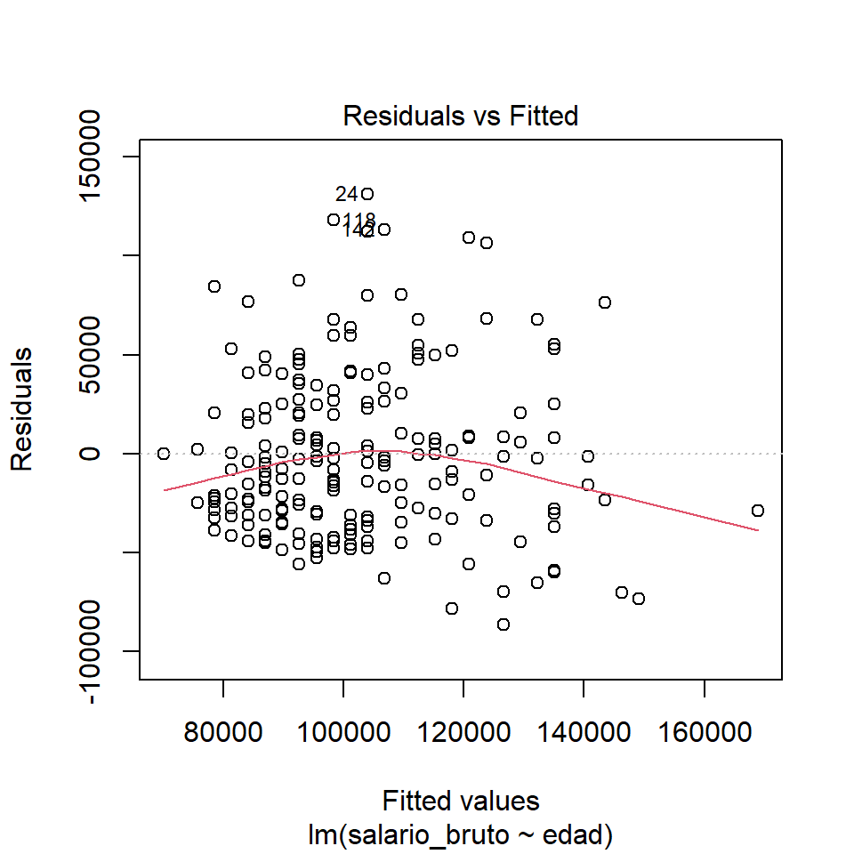

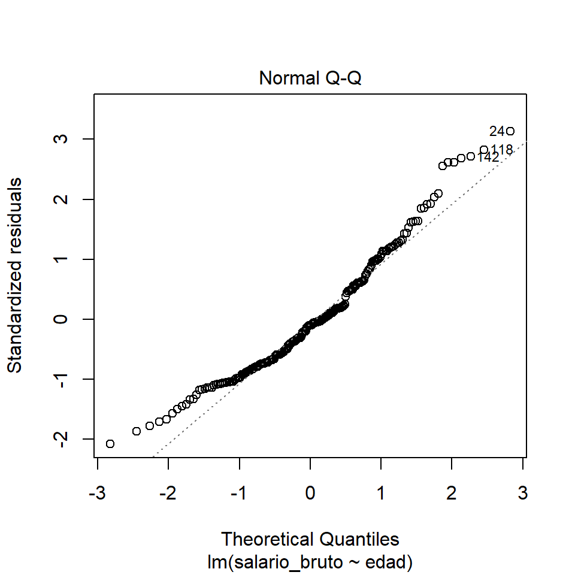

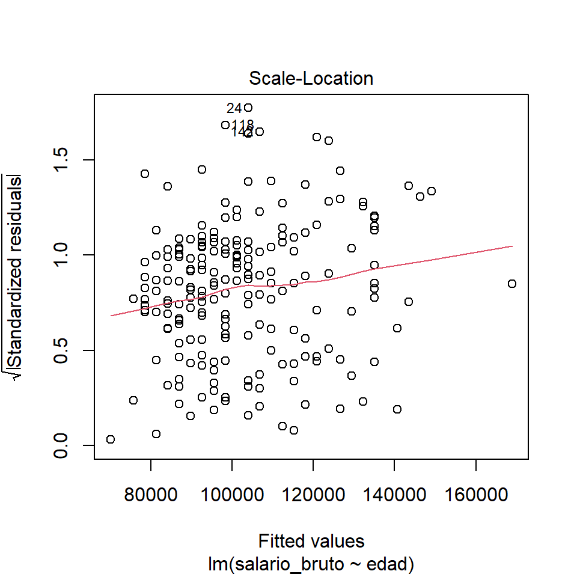

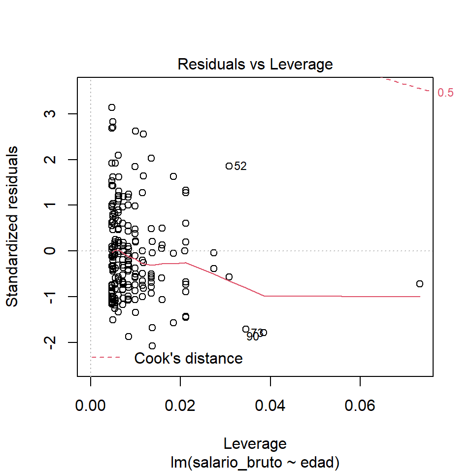

```r
plot(modelo_edad)
```

1. **Residuos** vs **valores predichos**: Parece existir cierta estructura en los datos: hay una leve curvatura
2. **Normal QQ plot**: los extremos no se ajustan a la distribución teórica
3. **Residual** vs **leverage**: Existen tres puntos con un leverage bastante alto, el gráfico destaca las observaciones 52, 73 y 90.

```r
encuesta_sueldos[52,]
```

| edad | anos_de_experiencia | anos_en_la_empresa_actual | anos_en_el_puesto_actual | perfil | salario_bruto | salario_neto |
| --- | --- | --- | --- | --- | --- | --- |
| 46 | 25 | 8 | 8 | BI Analyst / Data Analyst | 220000 | 150000 |

**Diagnóstico**: el modelo no cumple con los supuestos del modelo lineal. Parecen existir dos problemas: falta de normalidad y la presencia de observaciones de alto leverage

**Modelo de experiencia**

Observemos estos gráficos para el modelo de experiencia

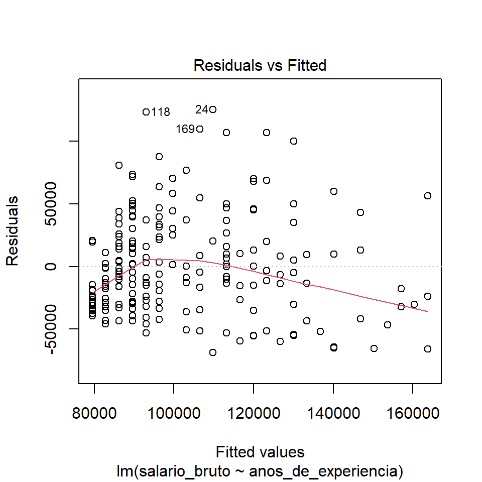

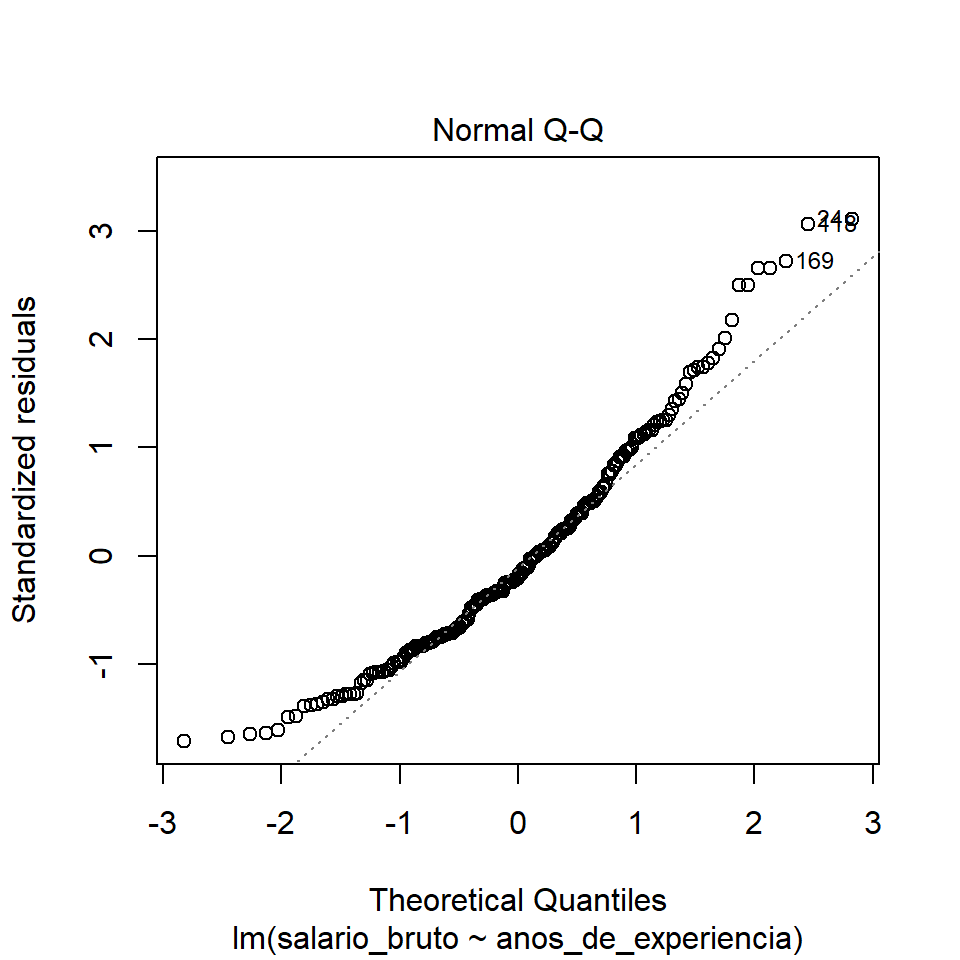

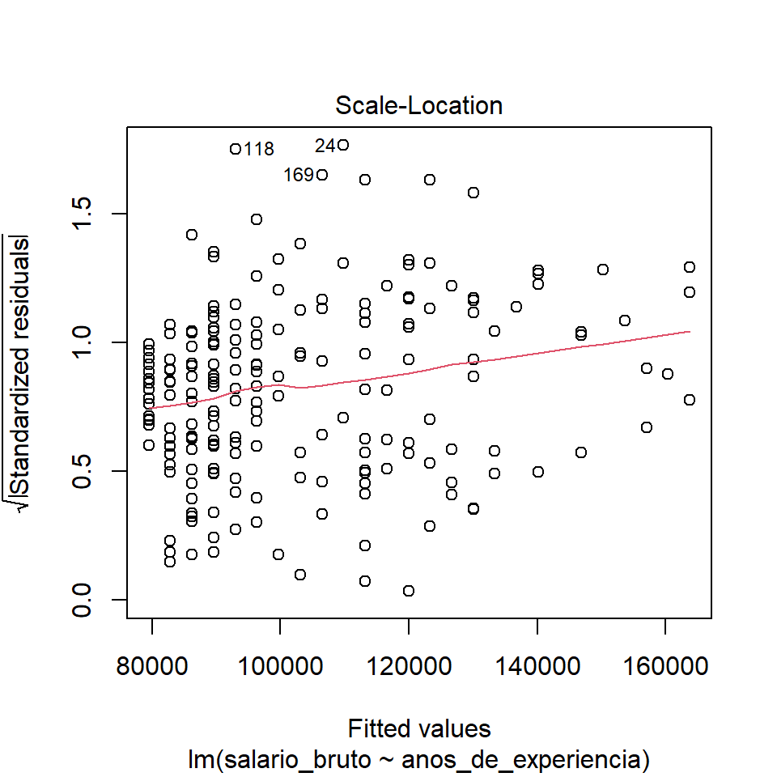

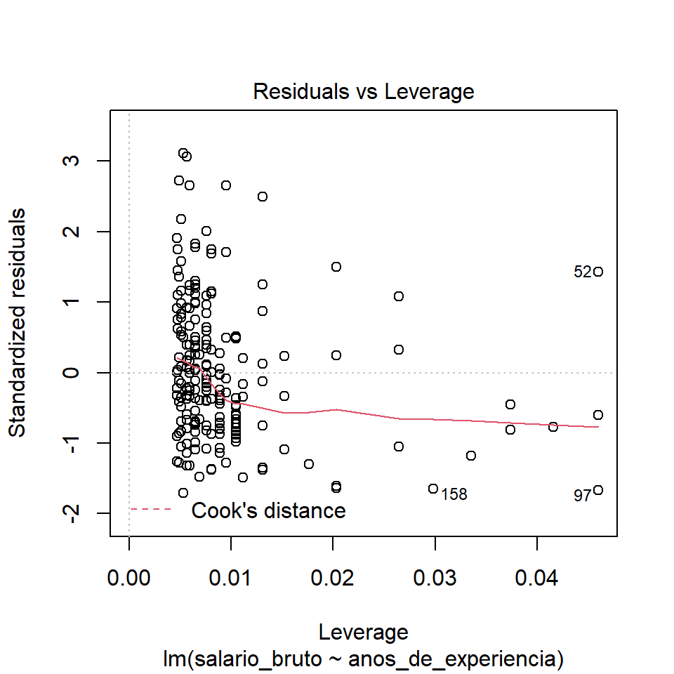

```r
plot(modelo_experiencia)
```

¿Qué observamos en este caso? ¿Qué diagnóstico darían?

### Broom: augment_columns

Con la función `augment_columns()` del paquete broom podemos agregar información a nuestro dataset original o a datos nuevos. Toma como argumentos: `x`: el modelo y `data`: nuestro dataset.

```r
# Agregamos las columnas
encuesta_aumentada = augment_columns(x=modelo_experiencia, data=encuesta_sueldos)
# Observamos los resultados
glimpse(encuesta_aumentada)
```

```
## Rows: 213
## Columns: 14
## $ edad                      <dbl> 26, 32, 40, 30, 30, 25, 35, 31, 27, 38, 24, ~
## $ anos_de_experiencia       <dbl> 3, 11, 4, 4, 6, 1, 10, 3, 2, 5, 3, 6, 1, 3, ~
## $ anos_en_la_empresa_actual <dbl> 1, 1, 0, 1, 2, 1, 1, 0, 0, 0, 3, 6, 0, 2, 2,~
## $ anos_en_el_puesto_actual  <dbl> 1, 1, 0, 4, 2, 1, 5, 2, 2, 0, 3, 2, 0, 1, 2,~
## $ perfil                    <chr> "Data Scientist / Data Engineer", "BI Analys~
## $ salario_bruto             <dbl> 75000, 90000, 40000, 84000, 125000, 40000, 1~
## $ salario_neto              <dbl> 68000, 75000, 34500, 68000, 93500, 34500, 89~
## $ .fitted                   <dbl> 89615.26, 116579.09, 92985.74, 92985.74, 997~
## $ .se.fit                   <dbl> 3250.641, 3347.575, 3037.682, 3037.682, 2786~
## $ .resid                    <dbl> -14615.264, -26579.093, -52985.743, -8985.74~
## $ .hat                      <dbl> 0.006497619, 0.006890917, 0.005674150, 0.005~
## $ .sigma                    <dbl> 40409.86, 40380.60, 40255.87, 40417.74, 4038~
## $ .cooksd                   <dbl> 4.323306e-04, 1.517573e-03, 4.953905e-03, 1.~
## $ .std.resid                <dbl> -0.3636054, -0.6613781, -1.3176583, -0.22345~
```

La función agregó varias columnas al dataset:

- .fitted: es el valor predicho
- .resid: es el residuo
- .std.resid: es el residuo estandarizado

Al contar con esta información como dataframe podemos trabajarla de diversas maneras. Por ejemplo, podemos realizar los gráficos de diagnóstico con ggplot

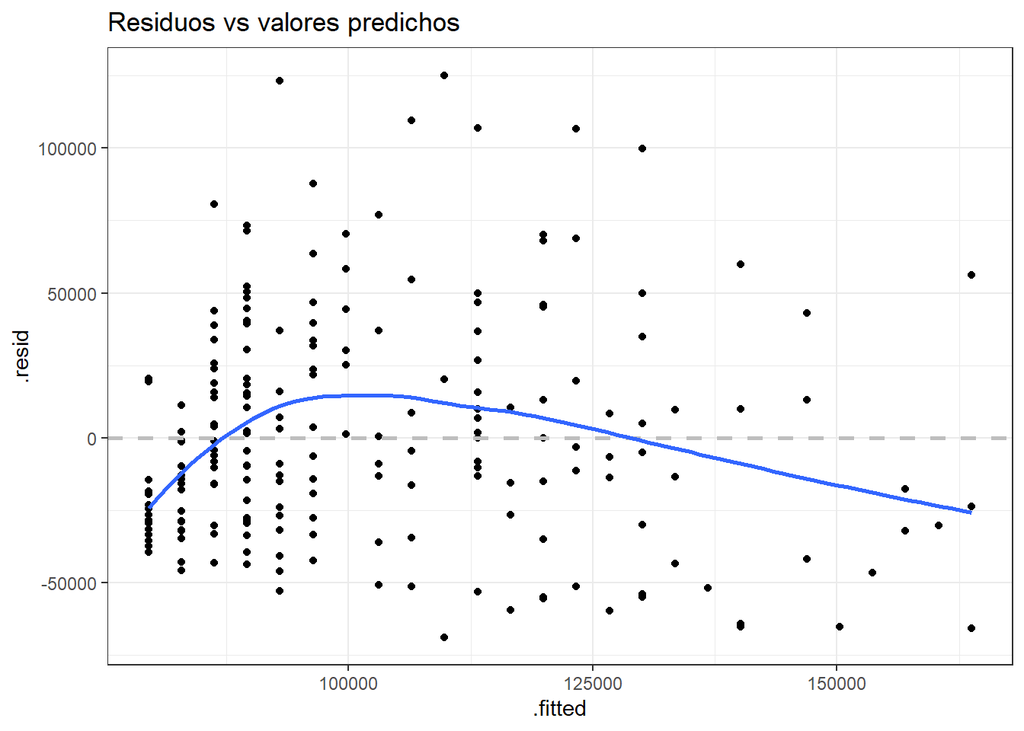

```r
ggplot(encuesta_aumentada, aes(.fitted, .resid)) +
  geom_point()+
  geom_hline(size = 1, colour = "grey", linetype="dashed", yintercept = 0) +
  geom_smooth(se = FALSE) +
  theme_bw() +
  labs(title = "Residuos vs valores predichos")
```

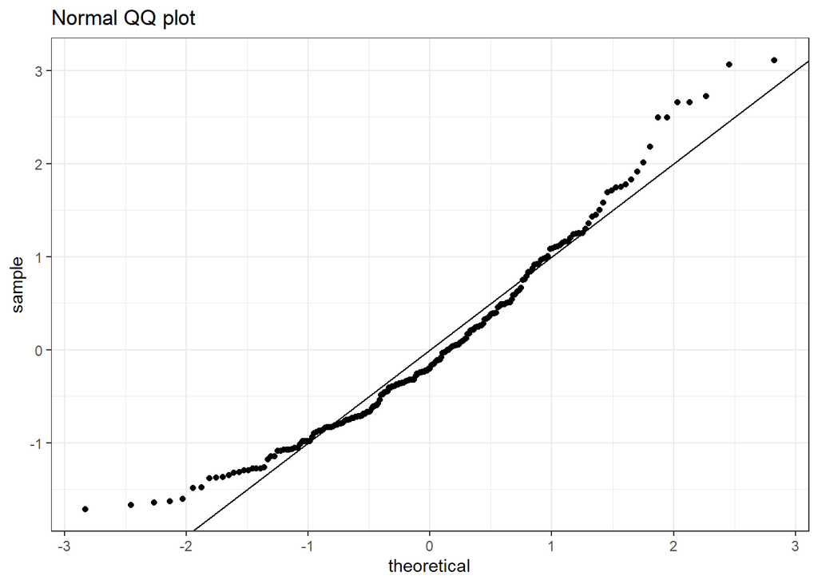

```r
ggplot(encuesta_aumentada, aes(sample= .std.resid))+
  stat_qq()+
  geom_abline() +
  theme_bw() +
  labs(title = "Normal QQ plot")
```

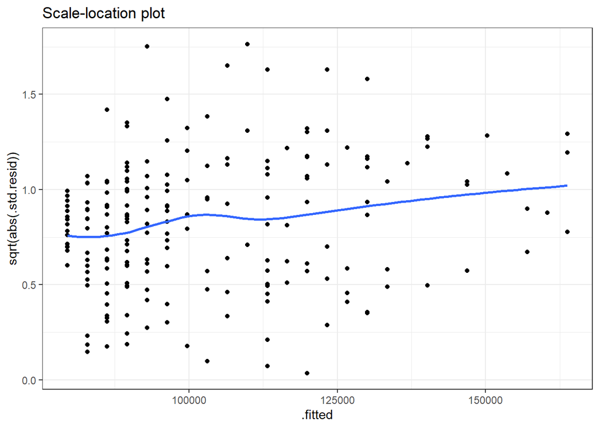

```r
ggplot(encuesta_aumentada, aes(.fitted, sqrt(abs(.std.resid))))+
  geom_point()+
  geom_smooth(se = FALSE) +
  theme_bw() +
  labs(title = "Scale-location plot")
```

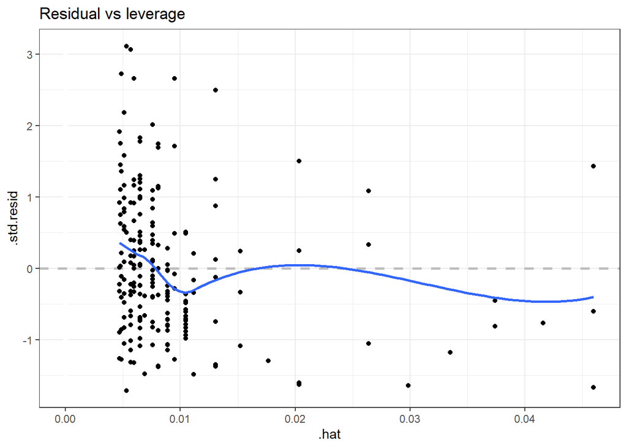

```r
ggplot(encuesta_aumentada, aes(.hat, .std.resid)) +
  geom_vline(size = 2, colour = "white", xintercept = 0) +
  geom_hline(size = 1, colour = "grey", linetype="dashed", yintercept = 0) +
  geom_point() + geom_smooth(se = FALSE) +
  theme_bw() +
  labs(title = "Residual vs leverage")
```